# Project: Investigate a Dataset no show appointments may 2016

- Introduction
- Data Wrangling
- Exploratory Data Analysis
- Conclusions

## Introduction

> The dataset selected is **no show appointments of may 2016**. This dataset collects information from 100k medical appointments in Brazil and is focused on the question of whether or not patients show up for their appointment. A number of characteristics about the patient are included in each row.

> The data type is categorical data  
> Charts could be used are bar, pie and line charts.

> The columns will be used are:  
> PatientId: The ID for each Patient  
> AppointmentID: The ID of Appointment for each patient  
> Gender: Patient's Gender  
> ScheduledDay: The day the patient set up their appointment  
> AppointmentDay: The day of patient's appointment  
> Age: Patient's Age  
> SMS_received: Is patient Receive SMS massege for their appointemnt day  
> No-show: Is patient not showed up to their appointment or showed up

> Questions
> 1. How many times patient show up and not show up, Is there is big difference between them??
> 2. What is gender of patient is the most and what showing up statue for each gender?
> 3. Proportion of Patients recevied SMS massege?
> 4. Is if SMS massage recevied affect on patient to show?
> 5. What is most Age stage of patient and what is the show up statue for each age stage?
> 6. What is Neighbourhood have most patients and what is the show up statue in each Neighbourhood?
> 7. What is period between schedueled and appointment days and is if period long affect on patient show up?

> I tried to do this investigate in easiest and fast performance code

```python
# Use this cell to set up import statements for all of the packages that you
#   plan to use.

# Remember to include a 'magic word' so that your visualizations are plotted
#   inline with the notebook. See this page for more:
#   http://ipython.readthedocs.io/en/stable/interactive/magics.html
import pandas as pd
import numpy as np
import matplotlib.pyplot as plt
%matplotlib inline
```

## Data Wrangling

> **Tip**: In this section of the report, you will load in the data, check for cleanliness, and then trim and clean your dataset for analysis. Make sure that you document your steps carefully and justify your cleaning decisions.

### General Properties(Data Assess)

```python
# Load data and print out a few lines.
df=pd.read_csv('noshowappointments-kagglev2-may-2016.csv')
df.head()
```

|  | PatientId | AppointmentID | Gender | ScheduledDay | AppointmentDay | Age | Neighbourhood | Scholarship | Hipertension | Diabetes | Alcoholism | Handcap | SMS_received | No-show |
| --- | --- | --- | --- | --- | --- | --- | --- | --- | --- | --- | --- | --- | --- | --- |
| 0 | 2.987250e+13 | 5642903 | F | 2016-04-29T18:38:08Z | 2016-04-29T00:00:00Z | 62 | JARDIM DA PENHA | 0 | 1 | 0 | 0 | 0 | 0 | No |
| 1 | 5.589978e+14 | 5642503 | M | 2016-04-29T16:08:27Z | 2016-04-29T00:00:00Z | 56 | JARDIM DA PENHA | 0 | 0 | 0 | 0 | 0 | 0 | No |
| 2 | 4.262962e+12 | 5642549 | F | 2016-04-29T16:19:04Z | 2016-04-29T00:00:00Z | 62 | MATA DA PRAIA | 0 | 0 | 0 | 0 | 0 | 0 | No |
| 3 | 8.679512e+11 | 5642828 | F | 2016-04-29T17:29:31Z | 2016-04-29T00:00:00Z | 8 | PONTAL DE CAMBURI | 0 | 0 | 0 | 0 | 0 | 0 | No |
| 4 | 8.841186e+12 | 5642494 | F | 2016-04-29T16:07:23Z | 2016-04-29T00:00:00Z | 56 | JARDIM DA PENHA | 0 | 1 | 1 | 0 | 0 | 0 | No |

```python
# Perform operations to inspect data
# types
df.dtypes
```

```
PatientId         float64
AppointmentID       int64
Gender             object
ScheduledDay       object
AppointmentDay     object
Age                 int64
Neighbourhood      object
Scholarship         int64
Hipertension        int64
Diabetes            int64
Alcoholism          int64
Handcap             int64
SMS_received        int64
No-show            object
dtype: object
```

```python
#look for instances of missing or possibly errant data.
df.info()
```

```
<class 'pandas.core.frame.DataFrame'>
RangeIndex: 110527 entries, 0 to 110526
Data columns (total 14 columns):
PatientId         110527 non-null float64
AppointmentID     110527 non-null int64
Gender            110527 non-null object
ScheduledDay      110527 non-null object
AppointmentDay    110527 non-null object
Age               110527 non-null int64
Neighbourhood     110527 non-null object
Scholarship       110527 non-null int64
Hipertension      110527 non-null int64
Diabetes          110527 non-null int64
Alcoholism        110527 non-null int64
Handcap           110527 non-null int64
SMS_received      110527 non-null int64
No-show           110527 non-null object
dtypes: float64(1), int64(8), object(5)
memory usage: 11.8+ MB
```

```python
sum(df.duplicated())
```

```
0
```

```python
df.nunique()
```

```
PatientId          62299
AppointmentID     110527
Gender                 2
ScheduledDay      103549
AppointmentDay        27
Age                  104
Neighbourhood         81
Scholarship            2
Hipertension           2
Diabetes               2
Alcoholism             2
Handcap                5
SMS_received           2
No-show                2
dtype: int64
```

```python
#Checks Ages values
df['Age'].describe()
```

```
count    110527.000000
mean         37.088874
std          23.110205
min          -1.000000
25%          18.000000
50%          37.000000
75%          55.000000
max         115.000000
Name: Age, dtype: float64
```

### Data Cleaning:

#### Remove columns not need

```python
# remove colums not need
df=df.drop([ 'AppointmentID','Scholarship', 'Hipertension','Diabetes','Alcoholism','Handcap'], axis=1)
```

```python
df.head(1)
```

|  | PatientId | Gender | ScheduledDay | AppointmentDay | Age | Neighbourhood | SMS_received | No-show |
| --- | --- | --- | --- | --- | --- | --- | --- | --- |
| 0 | 2.987250e+13 | F | 2016-04-29T18:38:08Z | 2016-04-29T00:00:00Z | 62 | JARDIM DA PENHA | 0 | No |

#### Remove Age with minuse value

```python
#remove -1 age
df=df[df.Age != -1]
df['Age'].describe()
```

```
count    110526.000000
mean         37.089219
std          23.110026
min           0.000000
25%          18.000000
50%          37.000000
75%          55.000000
max         115.000000
Name: Age, dtype: float64
```

#### Modify ScheduledDay and AppointmentDay columns to datetime data type)

```python
#the data type for ScheduledDay AppointmentDay need to be datetime type
# for calculate the period between them is long or short?
df['ScheduledDay'] = pd.to_datetime(df['ScheduledDay'])
df['AppointmentDay'] = pd.to_datetime(df['AppointmentDay'])
```

```python
df.dtypes
```

```
PatientId                float64
Gender                    object
ScheduledDay      datetime64[ns]
AppointmentDay    datetime64[ns]
Age                        int64
Neighbourhood             object
SMS_received               int64
No-show                   object
dtype: object
```

## Exploratory Data Analysis

### Research Question 1 (How many times patient show up and not show up, Is there is big difference between them?)

```python
df['No-show'].describe()
```

```
count     110526
unique         2
top           No
freq       88207
Name: No-show, dtype: object
```

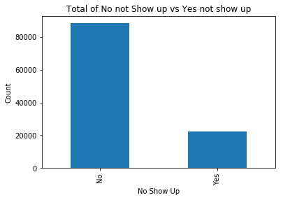

```python
df['No-show'].value_counts().plot(kind='bar');
plt.title('Total of No not Show up vs Yes not show up')
plt.xlabel('No Show Up')
plt.ylabel('Count')
plt.show();
#No mean Show
#Yes mean Not Show

#Using bar chart to understand the normal tendency, and the range of information for each value(distribution).
```

### Research Question 2 (What is gender of patient is the most and what showing up statue for each gender?)

```python
df.groupby(['No-show','Gender'])['PatientId'].count()
```

```
No-show  Gender
No       F         57245
         M         30962
Yes      F         14594
         M          7725
Name: PatientId, dtype: int64
```

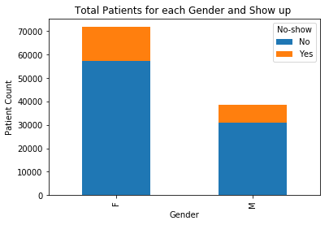

```python
df.groupby(['Gender','No-show'])['PatientId'].count().unstack().plot(kind='bar',stacked=True)
plt.title('Total Patients for each Gender and Show up ')
plt.xlabel('Gender')
plt.ylabel('Patient Count')
plt.show();

#Using stacked bar chart to show the composition of each gender being compared(composition)
```

### Research Question 3 (What is Proportion of Patients recevied SMS massege?)

```python
## Get the Proportion of patients of received_SMS and not received_SMS
prop=df.groupby('SMS_received')['PatientId'].count()/df['PatientId'].count()*100
```

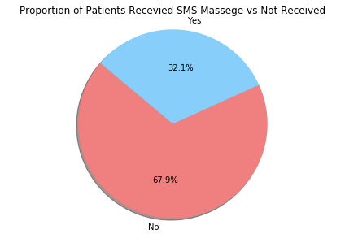

```python
import matplotlib.pyplot as plt

# Data to plot
labels = 'No', 'Yes'
sizes = prop
colors = ['lightcoral', 'lightskyblue']
explode = (0, 0)  # explode 1st slice

# Plot
plt.pie(sizes, explode=explode,labels=labels, colors=colors,autopct='%1.1f%%',
        shadow=True, startangle=140)
plt.tight_layout()
plt.title("Proportion of Patients Recevied SMS Massege vs Not Received")
plt.axis('equal')
plt.show()

# Calculate the Proportion of Patients Recevied SMS Massege and Not Received and plot it as pie chart
# is to see from all Patient 100% what is the Proportion of Patients Recevied SMS Massege and Not Received(composition)
```

### Research Question 4 (Is if SMS massage recevied affect on patient to show?)

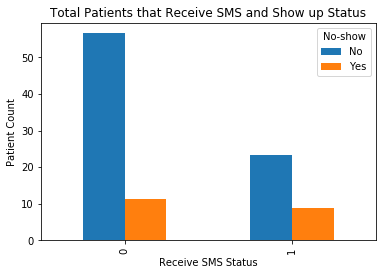

```python
# I will show both patients recevied and not recevied , it may let me for invstigate more thing
propPshowAndRecSMS= df.groupby(['SMS_received','No-show'])['PatientId'].count()/df['PatientId'].count()*100
propPshowAndRecSMS.unstack().plot(kind='bar')
plt.title('Total Patients that Receive SMS and Show up Status')
plt.xlabel('Receive SMS Status')
plt.ylabel('Patient Count')
plt.show();
# SMS_received:
# 0 mean not received SMS
# 1 received SMS

# Using bar chart is to show the low and high values of patinets receive SMS and show up,patinets receive SMS not show up
# and patinets not receive SMS and show up and patinets not receive SMS not show up(comparing)
```

### Research Question 5 (What is most Age stage of patient and what is the show up statue for each age stage?)

#### Divide the age into three stages (Child, Young, Old)

```python
cilddf=df[df.Age <=15]
cilddf['Age'].count()
```

```
24468
```

```python
childStag=np.repeat('Child',24468)
```

```python
adultdf= df[df['Age'].between(16,50)]
adultdf['Age'].count()
```

```
50635
```

```python
adultStag=np.repeat('Adult',50635)
```

```python
olddf=df[df.Age>=51]
olddf['Age'].count()
```

```
35423
```

```python
oldstag=np.repeat('Old',35423)
```

```python
df.sort_values('Age',inplace=True)
df.head()
```

|  | PatientId | Gender | ScheduledDay | AppointmentDay | Age | Neighbourhood | SMS_received | No-show |
| --- | --- | --- | --- | --- | --- | --- | --- | --- |
| 104654 | 8.822980e+14 | F | 2016-06-02 08:59:43 | 2016-06-02 | 0 | MONTE BELO | 0 | No |
| 44729 | 3.729549e+12 | M | 2016-04-28 12:44:54 | 2016-05-03 | 0 | INHANGUETÁ | 0 | No |
| 29671 | 9.997773e+13 | M | 2016-04-29 08:41:15 | 2016-05-02 | 0 | SÃO PEDRO | 0 | No |
| 42673 | 3.637132e+12 | M | 2016-05-09 10:21:59 | 2016-05-19 | 0 | MARIA ORTIZ | 0 | No |
| 42674 | 9.728985e+12 | M | 2016-04-18 13:29:49 | 2016-05-05 | 0 | JABOUR | 1 | No |

```python
AgeStag=[]
```

```python
AgeStag.extend(childStag)
```

```python
AgeStag.extend(adultStag)
```

```python
AgeStag.extend(oldstag)
```

```python
len(AgeStag)
```

```
110526
```

```python
df['Age-Stage']=AgeStag
df.head()
```

|  | PatientId | Gender | ScheduledDay | AppointmentDay | Age | Neighbourhood | SMS_received | No-show | Age-Stage |
| --- | --- | --- | --- | --- | --- | --- | --- | --- | --- |
| 104654 | 8.822980e+14 | F | 2016-06-02 08:59:43 | 2016-06-02 | 0 | MONTE BELO | 0 | No | Child |
| 44729 | 3.729549e+12 | M | 2016-04-28 12:44:54 | 2016-05-03 | 0 | INHANGUETÁ | 0 | No | Child |
| 29671 | 9.997773e+13 | M | 2016-04-29 08:41:15 | 2016-05-02 | 0 | SÃO PEDRO | 0 | No | Child |
| 42673 | 3.637132e+12 | M | 2016-05-09 10:21:59 | 2016-05-19 | 0 | MARIA ORTIZ | 0 | No | Child |
| 42674 | 9.728985e+12 | M | 2016-04-18 13:29:49 | 2016-05-05 | 0 | JABOUR | 1 | No | Child |

```python
df.tail()
```

|  | PatientId | Gender | ScheduledDay | AppointmentDay | Age | Neighbourhood | SMS_received | No-show | Age-Stage |
| --- | --- | --- | --- | --- | --- | --- | --- | --- | --- |
| 97666 | 7.482346e+14 | F | 2016-05-19 07:57:56 | 2016-06-03 | 115 | SÃO JOSÉ | 1 | No | Old |
| 68127 | 3.196321e+13 | F | 2016-04-08 14:29:17 | 2016-05-16 | 115 | ANDORINHAS | 0 | Yes | Old |
| 63912 | 3.196321e+13 | F | 2016-05-16 09:17:44 | 2016-05-19 | 115 | ANDORINHAS | 0 | Yes | Old |
| 76284 | 3.196321e+13 | F | 2016-05-30 09:44:51 | 2016-05-30 | 115 | ANDORINHAS | 0 | No | Old |
| 63915 | 3.196321e+13 | F | 2016-05-16 09:17:44 | 2016-05-19 | 115 | ANDORINHAS | 0 | Yes | Old |

```python
df['Age-Stage'].describe()
```

```
count     110526
unique         3
top        Adult
freq       50635
Name: Age-Stage, dtype: object
```

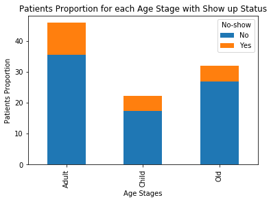

```python
propPshowAndRecSMS= df.groupby(['Age-Stage','No-show'])['PatientId'].count()/df['PatientId'].count()*100
propPshowAndRecSMS.unstack().plot(kind='bar',stacked=True)
plt.title('Patients Proportion for each Age Stage with Show up Status')
plt.xlabel('Age Stages')
plt.ylabel('Patients Proportion')
plt.show();
```

### Research Question 6 (What is Neighbourhood have most patients and what is the show up statue in each Neighbourhood?)

```python
df['Neighbourhood'].describe()
```

```
count             110526
unique                81
top       JARDIM CAMBURI
freq                7717
Name: Neighbourhood, dtype: object
```

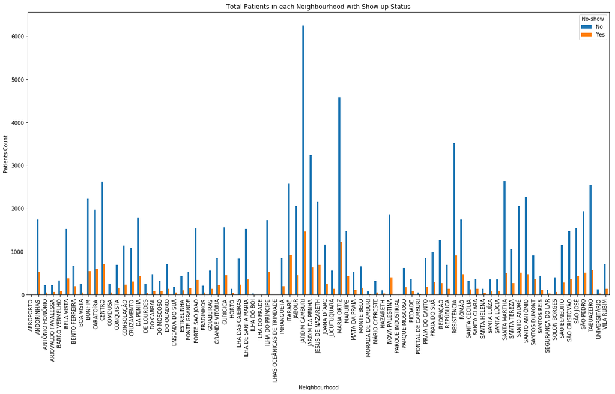

```python
df.groupby(['Neighbourhood','No-show'])['PatientId'].count().unstack().plot(kind='bar', figsize=(20,10))
plt.title('Total Patients in each Neighbourhood with Show up Status')
plt.xlabel('Neighbourhood')
plt.ylabel('Patients Count')
plt.show();
```

### Research Question 7 (What is period between schedueled and appointment days and is if period long affect on patient show up?)

#### compare between if period between schedueled and appointment days

```python
df['ScheduledDay'] = df['ScheduledDay'].dt.date
```

```python
df['ScheduledDay'] = pd.to_datetime(df['ScheduledDay'])
df['AppointmentDay'] = pd.to_datetime(df['AppointmentDay'])
```

```python
df['ScheduledDay'].describe()
```

```
count                  110526
unique                    111
top       2016-05-03 00:00:00
freq                     4238
first     2015-11-10 00:00:00
last      2016-06-08 00:00:00
Name: ScheduledDay, dtype: object
```

```python
PeriodDay=df['AppointmentDay'] - df['ScheduledDay']
df['PeriodDay']=PeriodDay
pd.to_datetime(df['PeriodDay'])
df['PeriodDay'] = df['PeriodDay'].dt.days
df.head()
```

|  | PatientId | Gender | ScheduledDay | AppointmentDay | Age | Neighbourhood | SMS_received | No-show | Age-Stage | PeriodDay |
| --- | --- | --- | --- | --- | --- | --- | --- | --- | --- | --- |
| 104654 | 8.822980e+14 | F | 2016-06-02 | 2016-06-02 | 0 | MONTE BELO | 0 | No | Child | 0 |
| 44729 | 3.729549e+12 | M | 2016-04-28 | 2016-05-03 | 0 | INHANGUETÁ | 0 | No | Child | 5 |
| 29671 | 9.997773e+13 | M | 2016-04-29 | 2016-05-02 | 0 | SÃO PEDRO | 0 | No | Child | 3 |
| 42673 | 3.637132e+12 | M | 2016-05-09 | 2016-05-19 | 0 | MARIA ORTIZ | 0 | No | Child | 10 |
| 42674 | 9.728985e+12 | M | 2016-04-18 | 2016-05-05 | 0 | JABOUR | 1 | No | Child | 17 |

```python
df=df[df['PeriodDay'] >= 0]
df.head()
```

|  | PatientId | Gender | ScheduledDay | AppointmentDay | Age | Neighbourhood | SMS_received | No-show | Age-Stage | PeriodDay |
| --- | --- | --- | --- | --- | --- | --- | --- | --- | --- | --- |
| 104654 | 8.822980e+14 | F | 2016-06-02 | 2016-06-02 | 0 | MONTE BELO | 0 | No | Child | 0 |
| 44729 | 3.729549e+12 | M | 2016-04-28 | 2016-05-03 | 0 | INHANGUETÁ | 0 | No | Child | 5 |
| 29671 | 9.997773e+13 | M | 2016-04-29 | 2016-05-02 | 0 | SÃO PEDRO | 0 | No | Child | 3 |
| 42673 | 3.637132e+12 | M | 2016-05-09 | 2016-05-19 | 0 | MARIA ORTIZ | 0 | No | Child | 10 |
| 42674 | 9.728985e+12 | M | 2016-04-18 | 2016-05-05 | 0 | JABOUR | 1 | No | Child | 17 |

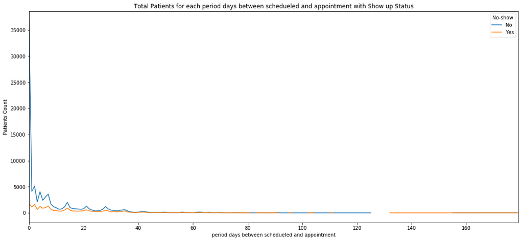

```python
df.groupby(['PeriodDay','No-show'])['PatientId'].count().unstack().plot(kind='line', figsize=(18,8))
plt.title('Total Patients for each period days between schedueled and appointment with Show up Status')
plt.xlabel('period days between schedueled and appointment')
plt.ylabel('Patients Count')
plt.show();
```

## Conclusions

#### Which period of age is mostly not show

```python
df_yes=df[df['No-show']== 'Yes']
df_yes.head()
```

|  | PatientId | Gender | ScheduledDay | AppointmentDay | Age | Neighbourhood | SMS_received | No-show | Age-Stage | PeriodDay |
| --- | --- | --- | --- | --- | --- | --- | --- | --- | --- | --- |
| 2707 | 1.213225e+14 | M | 2016-04-08 | 2016-04-29 | 0 | ILHA DAS CAIEIRAS | 1 | Yes | Child | 21 |
| 44730 | 8.839832e+14 | F | 2016-04-28 | 2016-05-10 | 0 | INHANGUETÁ | 1 | Yes | Child | 12 |
| 2674 | 7.549155e+14 | M | 2016-04-15 | 2016-04-29 | 0 | DO QUADRO | 1 | Yes | Child | 14 |
| 42667 | 9.682969e+11 | F | 2016-05-02 | 2016-05-12 | 0 | MARIA ORTIZ | 0 | Yes | Child | 10 |
| 44735 | 6.294176e+13 | M | 2016-04-28 | 2016-05-10 | 0 | INHANGUETÁ | 0 | Yes | Child | 12 |

```python
df_yes['SMS_received'].describe()
```

```
count    22314.000000
mean         0.438469
std          0.496211
min          0.000000
25%          0.000000
50%          0.000000
75%          1.000000
max          1.000000
Name: SMS_received, dtype: float64
```

```python
df_No=df[df['No-show']== 'No']
df_No.head()
```

|  | PatientId | Gender | ScheduledDay | AppointmentDay | Age | Neighbourhood | SMS_received | No-show | Age-Stage | PeriodDay |
| --- | --- | --- | --- | --- | --- | --- | --- | --- | --- | --- |
| 104654 | 8.822980e+14 | F | 2016-06-02 | 2016-06-02 | 0 | MONTE BELO | 0 | No | Child | 0 |
| 44729 | 3.729549e+12 | M | 2016-04-28 | 2016-05-03 | 0 | INHANGUETÁ | 0 | No | Child | 5 |
| 29671 | 9.997773e+13 | M | 2016-04-29 | 2016-05-02 | 0 | SÃO PEDRO | 0 | No | Child | 3 |
| 42673 | 3.637132e+12 | M | 2016-05-09 | 2016-05-19 | 0 | MARIA ORTIZ | 0 | No | Child | 10 |
| 42674 | 9.728985e+12 | M | 2016-04-18 | 2016-05-05 | 0 | JABOUR | 1 | No | Child | 17 |

```python
df_No['SMS_received'].describe()
```

```
count    88207.000000
mean         0.291337
std          0.454381
min          0.000000
25%          0.000000
50%          0.000000
75%          1.000000
max          1.000000
Name: SMS_received, dtype: float64
```

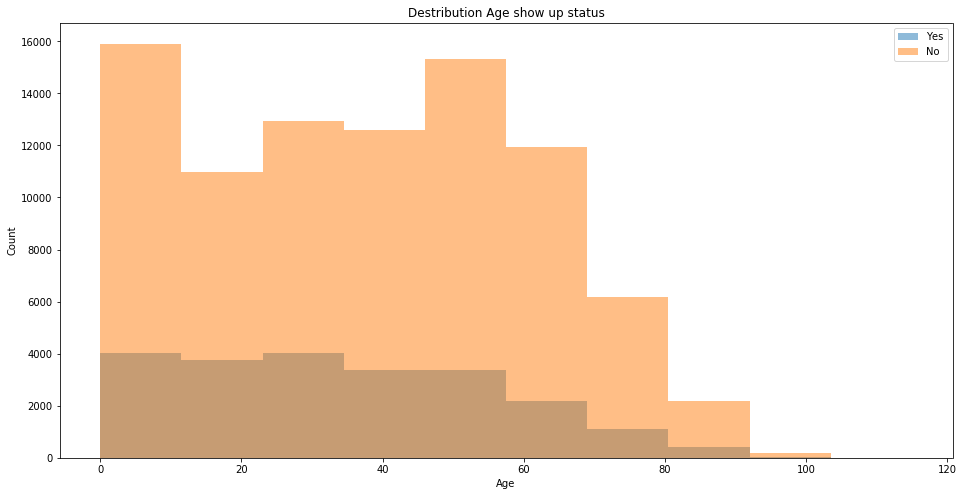

```python
fig,ax=plt.subplots(figsize=(16,8))
ax.hist(df_yes['Age'],alpha=0.5,label='Yes')
ax.hist(df_No['Age'],alpha=0.5,label='No')
ax.set_title('Destribution Age show up status')
ax.set_xlabel('Age')
ax.set_ylabel('Count')
ax.legend(loc='upper right')
plt.show();
```

> It seems like the most period age not show is from 0 age to 35 age  
> and most period age show is from 0 to 15

```python
from subprocess import call
call(['python', '-m', 'nbconvert', 'Investigate_a_Dataset.ipynb'])
```

```
0
```